# 2023_09_CNM_Fall

Cindy Fajardo

2023-11-07

#Libraries

```r
library("rerddap")
library(tidyverse)
library("tidync")
library("doParallel")
library(lubridate)
library(patchwork)
library(viridis)
library(here)
library(kableExtra)
library(dplyr)
library(ggplot2)
library(hrbrthemes)
library(emmeans)
library(agricolae)
library(vegan)
library(performance)
library(broom)
library(car)
```

#Read in CSV

```r
cnm_shell_length <- read_csv(here("Data","2023_09_CNM_OL_SL_Data.csv"))
cnm_mobiles <- read_csv(here("Data","2023_09_CNM_Mobile_Data.csv"))
cnm_mob_count_mat <- read_csv(here("Data", "2023_09_CNM_Mobile_Count_Matrix.csv"))
cnm_sessile_count_mat <- read_csv(here("Data", "2023_09_CNM_Sessile_Count_Matrix.csv"))
cnm_sessile <- read_csv(here("Data", "2023_09_CNM_Sessile_Data.csv"))
```

#Simple Statistics

```r
mean(cnm_shell_length$SL_mm)
```

```
## [1] 42.68119
```

```r
max(cnm_shell_length$SL_mm)
```

```
## [1] 77
```

```r
min(cnm_shell_length$SL_mm)
```

```
## [1] 15
```

#Density

```r
cnm_area <- 140 # area (m^2) that I surveyed at Cabrillo National Monument Zone 3
cnm_total_limpets <- nrow(cnm_shell_length)
pop_density_cnm <- cnm_total_limpets/cnm_area #calculate population density # of limpet/m^2
```

#Population Shell Length Distribution Graph

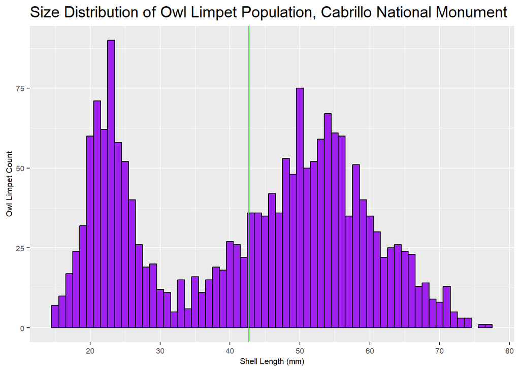

```r
cnm_pop_density <- cnm_shell_length %>% #calling csv with shell length data
  select(Limpet_No, SL_mm) %>% #selecting limpet number to count and shell length
  ggplot( aes(x=SL_mm)) + #Sl on x, I am not selecting y so R can use limpet count for density plot
  geom_bar(fill="purple",#color of bars
           colour="black",#color of bar outline
           alpha= 1,#transparency of bar
           width = 1) + #size of bars
  labs(title = "Size Distribution of Owl Limpet Population, Cabrillo National Monument",
       x = "Shell Length (mm)",
       y = "Owl Limpet Count")+
  theme(plot.title = element_text(size = 15),
        axis.title.y = element_text(size = 8),
        axis.title.x = element_text(size = 8),
        axis.text.x = element_text(size = 7),
        axis.text.y = element_text(size = 7))+
  scale_x_continuous(breaks = c(10,20,30,40,50,60,70,80))+ #lines I want to show up on x axis
  geom_vline(xintercept = mean(cnm_shell_length$SL_mm),
             colour="green")#draw line where average lies on density
 cnm_pop_density
```

#Size Distribution of Tagged Limpets

```r
tagged_limpets <- cnm_shell_length %>% #named new data frame using shell length data
  filter(Tag_ID != 0) #filtered out non-tagged limpets
tagged_limpets #calling data frame
```

```
## # A tibble: 140 × 5
##    Plot_Name Plot_Side Limpet_No SL_mm Tag_ID
##    <chr>     <chr>         <dbl> <dbl> <chr>
##  1 CNM_1     R                 3    56 D006
##  2 CNM_1     R                25    54 D002
##  3 CNM_1     R                49    44 D007
##  4 CNM_1     R                60    60 D003
##  5 CNM_1     R                75    65 D008
##  6 CNM_1     R                77    63 D004
##  7 CNM_1     R                95    62 D009
##  8 CNM_1     R                97    50 D010
##  9 CNM_1     R               107    27 D011
## 10 CNM_1     L               118    60 D005
## # ℹ 130 more rows
```

```r
mean(tagged_limpets$SL_mm)
```

```
## [1] 48.92143
```

#Tagged Limpets Shell Length Distribution Graph

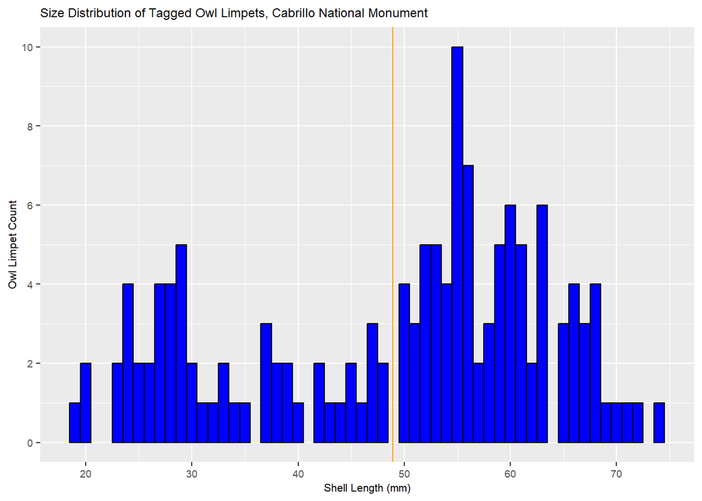

```r
tagged_distribution <- tagged_limpets %>% #calling data frame with tagged limpets only
  select(Limpet_No, SL_mm) %>% #selecting limpet number to count and shell length
  ggplot( aes(x=SL_mm)) + #Sl on x, I am not selecting y so R can use limpet count for density plot
  geom_bar(fill="blue",#color of bars
           colour="black",#color of bar outline
           alpha= 1,#transparency of bar
           width = 1) + #size of bars
  labs(title = "Size Distribution of Tagged Owl Limpets, Cabrillo National Monument",
       x = "Shell Length (mm)",
       y = "Owl Limpet Count")+
  theme(plot.title = element_text(size = 9),
        axis.title.y = element_text(size = 8),
        axis.title.x = element_text(size = 8),
        axis.text.x = element_text(size = 7),
        axis.text.y = element_text(size = 7))+
  scale_y_continuous(breaks = c(0,2,4,6,8,10))+ #lines I want to show up on y axis
  scale_x_continuous(breaks = c(10,20,30,40,50,60,70,80))+ #lines I want to show up on x axis
  geom_vline(xintercept = mean(tagged_limpets$SL_mm),
             colour="orange")#draw line where average lies on density
tagged_distribution
```

#Data Manipulation for Mobile Plots

```r
#Make some columns into factors
cnm_mobiles$COL_pres <- as.factor(cnm_mobiles$COL_pres) #made this coulmn a factor
cnm_mobiles$COL_pres_TF <- as.factor(cnm_mobiles$COL_pres_TF) #made this coulmn a factor THIS IMPORTANT FOR nMDS
cnm_mobiles$Transect<- as.factor(cnm_mobiles$Transect)


cnm_mobiles_long <- cnm_mobiles %>%
  pivot_longer(cols = A_lugubris:L_gigantea, #pivoted to make longer
               names_to = "Species", #all species name in this column
               values_to = "Count") %>%  #all counts of said species in this column, this can give me a count per species to get species abundance
  filter(Count != 0) %>% #take out any rows that have a count of 0, R was giving me problems. Some plots were selected againts since they had 0 for all species
  group_by(COL_pres) %>% #group by presence or no presence of owl limpet
  count(Species) #provide count of each species by group
  #mutate(Spec_rich = (n/1963.5)*100) #create new column with species richness


cnm_mobiles_long_3 <- cnm_mobiles %>%
  pivot_longer(cols = A_lugubris:L_gigantea, #pivoted to make longer
               names_to = "Species", #all species name in this column
               values_to = "Count") %>%   #all counts of said species in this column, this can give me a count per species to get species abundance
  #filter(Count != 0) %>% #take out any rows that have a count of 0, R was giving me problems. Some plots were selected againts since they had 0 for all species
  group_by(Plot_Name) %>% #group by presence or no presence of owl limpet
  count(Species) #provide count of each species by group

##########THIS IS THE ONE THAT WORKS############
cnm_mobiles_sum_spec <- cnm_mobiles %>%
  mutate(spec_sum = rowSums(across(c(A_lugubris, L_plena, L_limatula, L_scabra, Nuttallina_sp, P_crassipes, T_funebralis, L_gigantea)), na.rm=TRUE)) %>%
   pivot_longer(cols = A_lugubris:L_gigantea, #pivoted to make longer
               names_to = "Species", #all species name in this column
               values_to = "Count")
```

#Boxplot of Mobile Organism Abundance Per Plot in Presence/Absence of Central Limpet

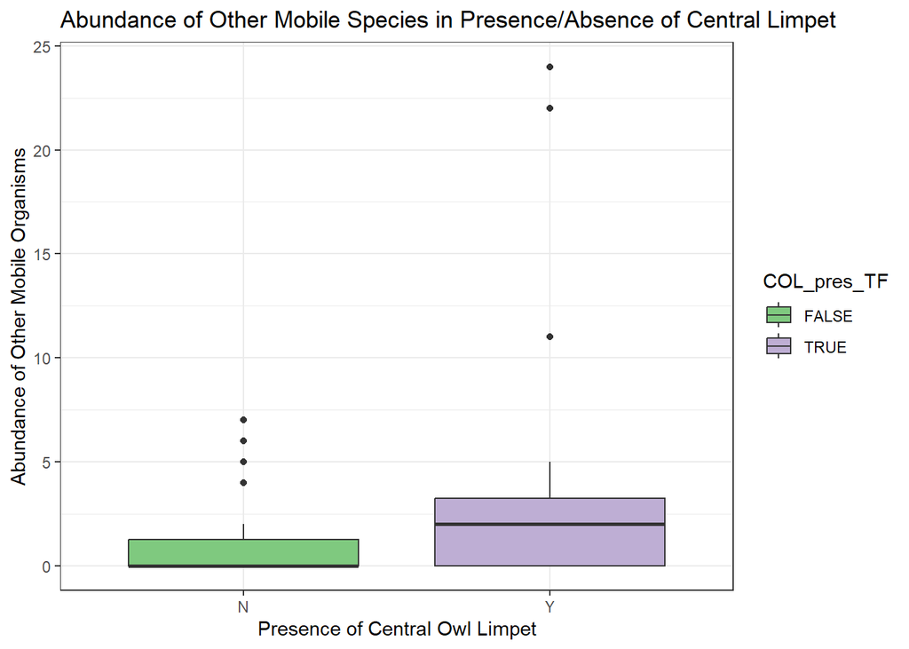

```r
 cnm_mobiles_sum_spec %>%
  ggplot(aes(
    x = COL_pres,
    y = spec_sum,
    fill = COL_pres_TF))+
  geom_boxplot(show.legend = TRUE)+
  scale_fill_brewer(palette = "Accent")+
  labs(title = "Abundance of Other Mobile Species in Presence/Absence of Central Limpet",
       x = "Presence of Central Owl Limpet",
       y = "Abundance of Other Mobile Organisms") +
  theme_bw()
```

#Sessile Species Abundance Using Percent Cover

```r
#Make columns into factors
cnm_sessile$COL_pres <- as.factor(cnm_sessile$COL_pres)
cnm_sessile$COL_pres_TF <- as.factor(cnm_sessile$COL_pres_TF) #made this coulmn a factor THIS IMPORTANT FOR nMDS
cnm_sessile$Transect<- as.factor(cnm_sessile$Transect)

cnm_sessile_sum_plot <- cnm_sessile %>%
  mutate(spec_sum = rowSums(across(c(A_elegantissima,Chthalmus_sp, Bare_rock, Ralfsia_sp, P_polymerus, Ulva_sp)), na.rm=TRUE))%>%
   pivot_longer(cols = A_elegantissima:Ulva_sp, #pivoted to make longer
               names_to = "Species", #all species name in this column
               values_to = "Count") %>%
  mutate(count_sa = Count/spec_sum) %>%
  mutate(percent_cover = count_sa*100) %>%
  group_by(Transect)
```

#Boxplot of Sessile Organism Percent Cover Per Plot in Presence/Absence of Central Limpet

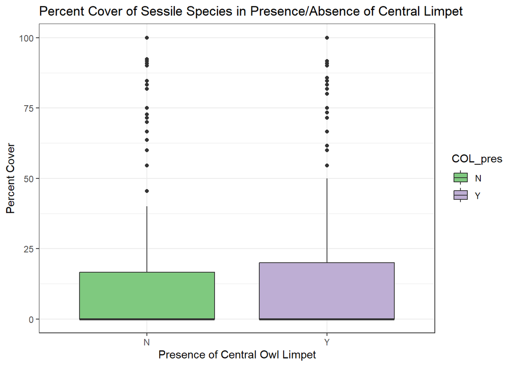

```r
cnm_sessile_sum_plot %>%
  ggplot(aes(
    x = COL_pres,
    y = percent_cover,
    fill = COL_pres))+
  geom_boxplot(show.legend = TRUE)+
  scale_fill_brewer(palette = "Accent")+
  labs(title = "Percent Cover of Sessile Species in Presence/Absence of Central Limpet",
       x = "Presence of Central Owl Limpet",
       y = "Percent Cover") +
  theme_bw()
```

#Permanova of mobile species abundance

```r
cnm_mobiles_labels <- cnm_mobiles[,-c(1:7)] %>% #made labels using species names. It didn't work when I add this piece of code to the nMDS plot
  pivot_longer(cols = A_lugubris:L_gigantea,
               names_to = "Species",
               values_to = "Count")

cnm_mobiles_sum <- cnm_mobiles%>% #I created a new data frame with the addition of the sum of individuals per species in each plot
  mutate(Sum = sum(A_lugubris, L_plena, L_limatula, L_scabra, Nuttallina_sp, P_crassipes, T_funebralis, L_gigantea)) %>%
  filter(Sum != 0) #model doesn't work if sum column has 0s

cnm_mobiles_sum_pivot <- cnm_mobiles_sum %>%
  pivot_longer(cols = A_lugubris:L_gigantea, #pivoted to make longer
               names_to = "Species", #all species name in this column
               values_to = "Count") %>%
  group_by(Plot_Name) %>%
  count(Species)

model1<-adonis2(cnm_mobiles_sum[,-c(1:7)]~COL_pres_TF, cnm_mobiles_sum, permutations = 999,
                method="bray")
model1
```

```
## Permutation test for adonis under reduced model
## Terms added sequentially (first to last)
## Permutation: free
## Number of permutations: 999
##
## adonis2(formula = cnm_mobiles_sum[, -c(1:7)] ~ COL_pres_TF, data = cnm_mobiles_sum, permutations = 999, method = "bray")
##             Df  SumOfSqs      R2      F Pr(>F)
## COL_pres_TF  1 0.0004509 0.03806 2.7693  0.071 .
## Residual    70 0.0113974 0.96194
## Total       71 0.0118483 1.00000
## ---
## Signif. codes:  0 '***' 0.001 '**' 0.01 '*' 0.05 '.' 0.1 ' ' 1
```

```r
coeffs <- tidy(model1)
coeffs
```

```
## # A tibble: 3 × 6
##   term           df SumOfSqs     R2 statistic p.value
##   <chr>       <dbl>    <dbl>  <dbl>     <dbl>   <dbl>
## 1 COL_pres_TF     1 0.000451 0.0381      2.77   0.071
## 2 Residual       70 0.0114   0.962      NA     NA
## 3 Total          71 0.0118   1          NA     NA
```

#Permanova of Mobile Species Matrix

```r
cnm_mob_count_mat$COL_pres <- as.factor(cnm_mob_count_mat$COL_pres) #made this coulmn a factor
cnm_mob_count_mat$COL_pres_TF <- as.factor(cnm_mob_count_mat$COL_pres_TF) #made this coulmn a factor THIS IMPORTANT FOR nMDS
cnm_mob_count_mat$Transect<- as.factor(cnm_mob_count_mat$Transect)

cnm_mob_count_sum <- cnm_mob_count_mat%>% #I created a new data frame with the addition of the sum of counts per species in each plot using a data matrix made up of 0 and 1. 1 represents the occurence of that species in that plot.
  mutate(Sum = sum(A_lugubris, L_plena, L_limatula, L_scabra, Nuttallina_sp, P_crassipes, T_funebralis, L_gigantea)) %>%
  filter(Sum != 0) #permanova did not accept 0

model2<-adonis2(cnm_mob_count_sum[,-c(1:7)]~COL_pres_TF, cnm_mob_count_sum, permutations = 999, method="bray") #independent variable is the presence or absence of limpets
model2
```

```
## Permutation test for adonis under reduced model
## Terms added sequentially (first to last)
## Permutation: free
## Number of permutations: 999
##
## adonis2(formula = cnm_mob_count_sum[, -c(1:7)] ~ COL_pres_TF, data = cnm_mob_count_sum, permutations = 999, method = "bray")
##             Df  SumOfSqs      R2      F Pr(>F)
## COL_pres_TF  1 0.0005328 0.09346 7.2169  0.004 **
## Residual    70 0.0051676 0.90654
## Total       71 0.0057004 1.00000
## ---
## Signif. codes:  0 '***' 0.001 '**' 0.01 '*' 0.05 '.' 0.1 ' ' 1
```

#nMDS of Mobile Species Abundance in the Presence/Absence of Owl Limpet

```r
disper<-vegdist(cnm_mobiles_sum[,-c(1:7)]) #calculate distance matrix
cnm_mobile_distmat <- as.matrix(disper, labels = T) #used distance matrix as easy to view matrix


cnm_mobile_NMS <-
  metaMDS(cnm_mobile_distmat,#used metaMDS to make NMS to use in nMDS plot
          distance = "bray",
          k = 2,
          maxit = 999,
          trymax = 500,
          wascores = TRUE)
```

```
## *** Best solution repeated 1 times
```

```r
cnm_mobile_NMS
```

```
##
## Call:
## metaMDS(comm = cnm_mobile_distmat, distance = "bray", k = 2,      trymax = 500, wascores = TRUE, maxit = 999)
##
## global Multidimensional Scaling using monoMDS
##
## Data:     cnm_mobile_distmat
## Distance: user supplied
##
## Dimensions: 2
## Stress:     0.05073685
## Stress type 1, weak ties
## Best solution was repeated 1 time in 20 tries
## The best solution was from try 19 (random start)
## Scaling: centring, PC rotation
## Species: scores missing
```

```r
cnm_mobile_NMS$stress
```

```
## [1] 0.05073685
```

```r
# Shepards test/goodness of fit
goodness(cnm_mobile_NMS) # Produces a results of test statistics for goodness of fit for each point
```

```
##  [1] 0.0008509296 0.0021757391 0.0008509296 0.0021757391 0.0008509296
##  [6] 0.0162012731 0.0008509296 0.0065501124 0.0021757391 0.0034298274
## [11] 0.0021757391 0.0029311763 0.0031299821 0.0008509296 0.0008509296
## [16] 0.0021757391 0.0094734102 0.0112205068 0.0021757391 0.0008509296
## [21] 0.0071317363 0.0008509296 0.0088987986 0.0008509296 0.0148181400
## [26] 0.0008509296 0.0101571978 0.0090787128 0.0033849000 0.0008509296
## [31] 0.0008509296 0.0008509296 0.0054913443 0.0089097865 0.0031299821
## [36] 0.0089456139 0.0189856752 0.0034298274 0.0008509296 0.0051736566
## [41] 0.0008509296 0.0008509296 0.0086137922 0.0069697429 0.0036987531
## [46] 0.0008509296 0.0008509296 0.0008509296 0.0033849000 0.0008509296
## [51] 0.0053024425 0.0008509296 0.0053024425 0.0008509296 0.0008509296
## [56] 0.0008509296 0.0008509296 0.0008509296 0.0033849000 0.0008509296
## [61] 0.0008509296 0.0008509296 0.0078595375 0.0008509296 0.0115514446
## [66] 0.0008509296 0.0144178262 0.0029311763 0.0108244655 0.0029311763
## [71] 0.0085680395 0.0008509296
```

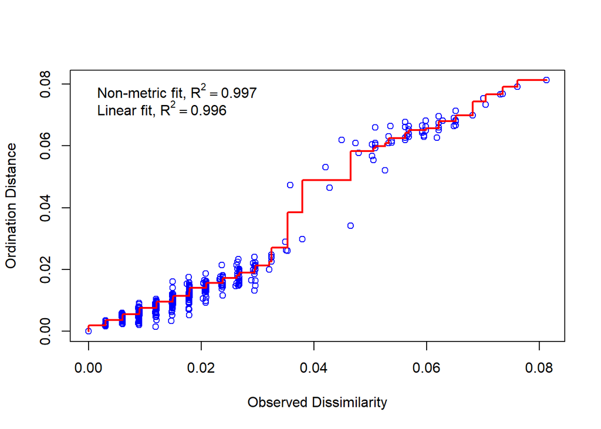

```r
stressplot(cnm_mobile_NMS) # Produces a Shepards diagram
```

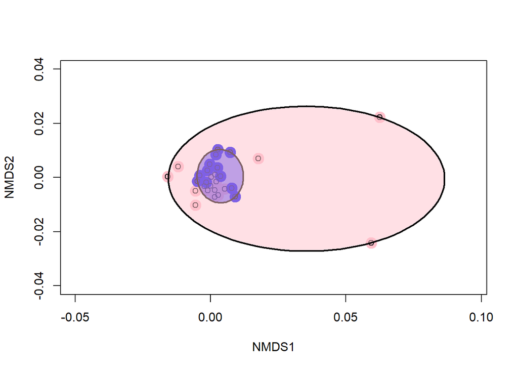

```r
plot(cnm_mobile_NMS, #making nMDS plot, calling the NMS to use in formula
     ylim=c(-0.04,0.04)) %>%
     points(points(cnm_mobile_NMS$points[cnm_mobiles_sum$COL_pres_TF=='TRUE',1],cnm_mobile_NMS$points[cnm_mobiles_sum$COL_pres_TF=='TRUE',2],
            pch=19, col='pink', cex=2)) %>%
            points(points(cnm_mobile_NMS$points[cnm_mobiles_sum$COL_pres_TF=='FALSE',1],cnm_mobile_NMS$points[cnm_mobiles_sum$COL_pres_TF=='FALSE',2],
                          pch=19, col='blue', cex=2)) %>%
  ordiellipse(cnm_mobile_NMS, groups=cnm_mobiles_sum$COL_pres_TF, display = "sites", kind='ehull', border='black', col=c('blue','pink'), lwd=2, draw ='polygon')
```

#nMDS of Mobile Species Richness in the Presence/Absence of Owl Limpet

```r
disper<-vegdist(cnm_mob_count_sum[,-c(1:7)])#calculate distance matrix
cnm_mob_count_sum_distmat <- as.matrix(disper, labels = T) #easy to view matrix


cnm_mob_count_NMS <-metaMDS(cnm_mob_count_sum_distmat, #used metaMDS to make NMS to use in nMDS plot
          distance = "bray",
          k = 2,
          maxit = 999,
          trymax = 500,
          wascores = TRUE)
```

```
## *** Best solution repeated 1 times
```

```r
# Shepards test/goodness of fit
goodness(cnm_mob_count_NMS) # Produces a results of test statistics for goodness of fit for each point
```

```
##  [1] 0.001959135 0.005162213 0.001959135 0.005162213 0.001959135 0.029788136
##  [7] 0.001959135 0.005116208 0.005162213 0.005116208 0.005162213 0.005116208
## [13] 0.004869078 0.001959135 0.001959135 0.005162213 0.015313878 0.018993358
## [19] 0.005162213 0.001959135 0.011083702 0.001959135 0.005162213 0.001959135
## [25] 0.011510852 0.001959135 0.011083702 0.028840782 0.005162213 0.001959135
## [31] 0.001959135 0.001959135 0.011510852 0.033800910 0.004869078 0.011510852
## [37] 0.015313878 0.005116208 0.005162213 0.004869078 0.001959135 0.001959135
## [43] 0.016400160 0.005116208 0.004869078 0.001959135 0.001959135 0.001959135
## [49] 0.005162213 0.001959135 0.005162213 0.001959135 0.005162213 0.001959135
## [55] 0.001959135 0.001959135 0.001959135 0.001959135 0.005162213 0.001959135
## [61] 0.001959135 0.001959135 0.018993358 0.001959135 0.015038280 0.001959135
## [67] 0.017798276 0.005116208 0.026196625 0.005116208 0.026893087 0.001959135
```

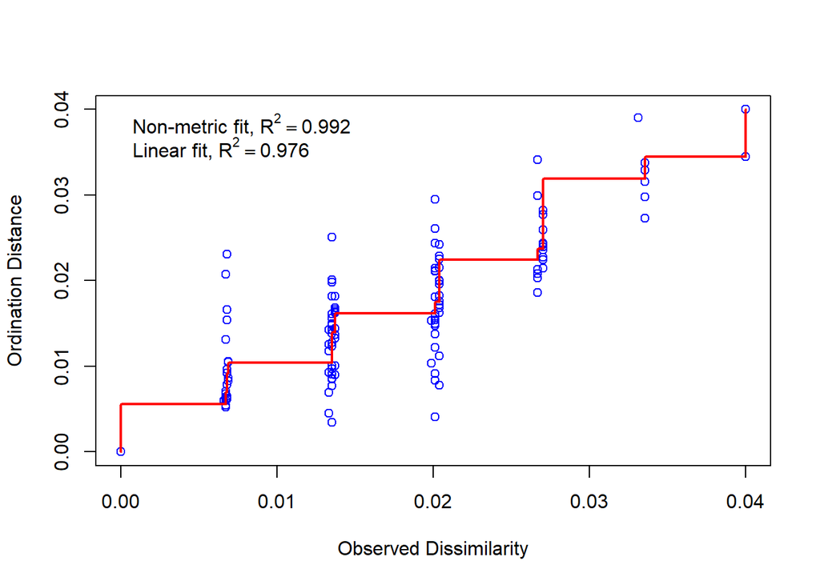

```r
stressplot(cnm_mob_count_NMS) # Produces a Shepards diagram
```

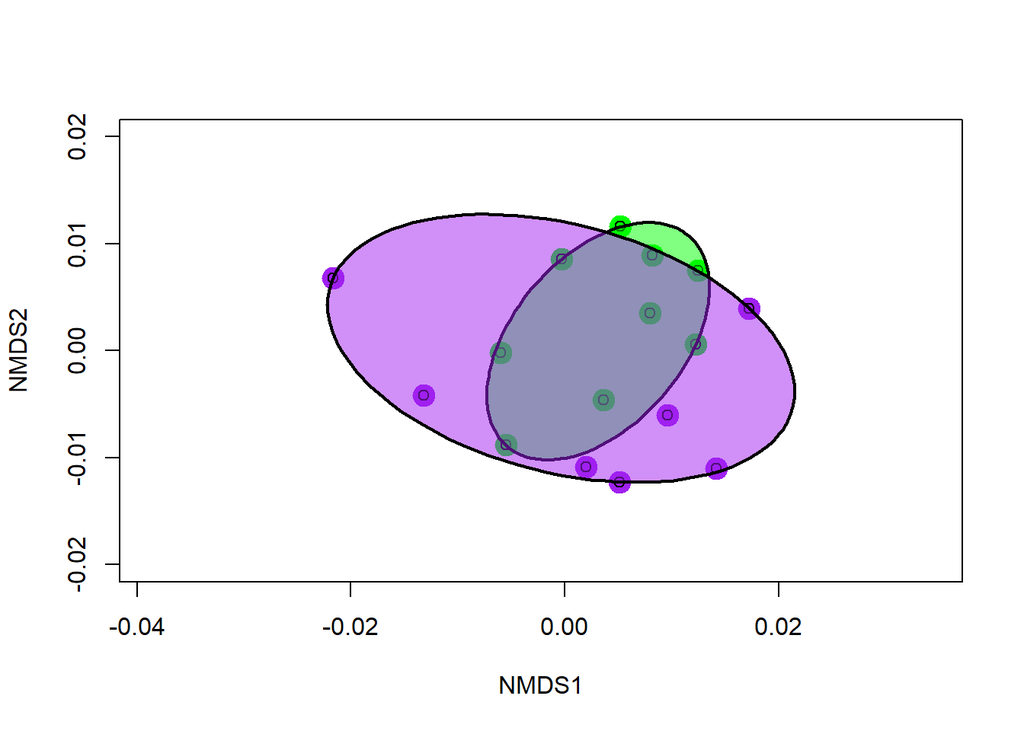

```r
plot(cnm_mob_count_NMS,
     ylim=c(-0.02,0.02)) %>%
     points(points(cnm_mob_count_NMS$points[cnm_mob_count_sum$COL_pres_TF=='TRUE',1],cnm_mob_count_NMS$points[cnm_mob_count_sum$COL_pres_TF=='TRUE',2],
            pch=19, col='purple', cex=2)) %>%
            points(points(cnm_mob_count_NMS$points[cnm_mob_count_sum$COL_pres_TF=='FALSE',1],cnm_mob_count_NMS$points[cnm_mob_count_sum$COL_pres_TF=='FALSE',2],
                          pch=19, col='green', cex=2)) %>%
  ordiellipse(cnm_mob_count_NMS, groups=cnm_mob_count_sum$COL_pres_TF, display = "sites", kind='ehull', border='black', col=c('green','purple'), lwd=2, draw ='polygon')
```

#Linear Regression of Limpet Presence/absence vs total mobile abundance per Transect

```r
cnm_mobiles_long_2 <- cnm_mobiles %>%
  pivot_longer(cols = A_lugubris:L_gigantea, #pivoted to make longer
               names_to = "Species", #all species name in this column
               values_to = "Count") %>%  #all counts of said species in this column, this can give me a count per species to get species richness
  filter(Count != 0) %>% #take out any rows that have a count of 0, R was giving me problems. Some plots were selected against since they had 0 for all species
  group_by(Transect, COL_pres) %>%
  count(Species)# %>% #provide count of each species by group
  #mutate(Spec_rich = (n/1963.5)*100)
model_mob_lin_reg <- glm(COL_pres~n, family = "binomial"(link = "logit"), data = cnm_mobiles_long_2)
model_mob_lin_reg
```

```
##
## Call:  glm(formula = COL_pres ~ n, family = binomial(link = "logit"),
##     data = cnm_mobiles_long_2)
##
## Coefficients:
## (Intercept)            n
##     0.74320     -0.02318
##
## Degrees of Freedom: 32 Total (i.e. Null);  31 Residual
## Null Deviance:       42.01
## Residual Deviance: 42    AIC: 46
```

```r
Anova(model_mob_lin_reg)
```

```
## Analysis of Deviance Table (Type II tests)
##
## Response: COL_pres
##    LR Chisq Df Pr(>Chisq)
## n 0.0077454  1     0.9299
```

```r
library(pscl)
pR2(model_mob_lin_reg)
```

```
## fitting null model for pseudo-r2
```

```
##           llh       llhNull            G2      McFadden          r2ML
## -2.100109e+01 -2.100497e+01  7.745354e-03  1.843696e-04  2.346801e-04
##          r2CU
##  3.259367e-04
```

```r
#########MIGHT GO WITH THIS ONE###############
cnm_mobiles_sum_spec$spec_sum <- as.factor(cnm_mobiles_sum_spec$spec_sum)
model2_mob_lin_reg <- glm(spec_sum~COL_pres_TF, family = "binomial"(link = "logit"), data = cnm_mobiles_sum_spec)
model2_mob_lin_reg
```

```
##
## Call:  glm(formula = spec_sum ~ COL_pres_TF, family = binomial(link = "logit"),
##     data = cnm_mobiles_sum_spec)
##
## Coefficients:
##     (Intercept)  COL_pres_TFTRUE
##         -0.2231           0.9163
##
## Degrees of Freedom: 575 Total (i.e. Null);  574 Residual
## Null Deviance:       791.4
## Residual Deviance: 762.3     AIC: 766.3
```

```r
Anova(model2_mob_lin_reg)
```

```
## Analysis of Deviance Table (Type II tests)
##
## Response: spec_sum
##             LR Chisq Df Pr(>Chisq)
## COL_pres_TF   29.058  1  7.025e-08 ***
## ---
## Signif. codes:  0 '***' 0.001 '**' 0.01 '*' 0.05 '.' 0.1 ' ' 1
```

```r
pR2(model2_mob_lin_reg)
```

```
## fitting null model for pseudo-r2
```

```
##           llh       llhNull            G2      McFadden          r2ML
## -381.16101453 -395.68986812   29.05770718    0.03671778    0.04919607
##          r2CU
##    0.06586807
```

#Linear Regression of Sessile Percent Cover vs Presence/absence of Owl limpet

```r
cnm_sessile_sum_plot$Count <- as.factor(cnm_sessile_sum_plot$Count)
model1_sessile_lin_reg <- glm(Count~COL_pres, family = "binomial"(link = "logit"), data = cnm_sessile_sum_plot)
model1_sessile_lin_reg
```

```
##
## Call:  glm(formula = Count ~ COL_pres, family = binomial(link = "logit"),
##     data = cnm_sessile_sum_plot)
##
## Coefficients:
## (Intercept)    COL_presY
##    -0.73632      0.04317
##
## Degrees of Freedom: 425 Total (i.e. Null);  424 Residual
## Null Deviance:       539.5
## Residual Deviance: 539.5     AIC: 543.5
```

```r
Anova(model1_sessile_lin_reg)
```

```
## Analysis of Deviance Table (Type II tests)
##
## Response: Count
##          LR Chisq Df Pr(>Chisq)
## COL_pres 0.043778  1     0.8343
```

```r
pR2(model1_sessile_lin_reg)
```

```
## fitting null model for pseudo-r2
```

```
##           llh       llhNull            G2      McFadden          r2ML
## -2.697257e+02 -2.697476e+02  4.377756e-02  8.114542e-05  1.027589e-04
##          r2CU
##  1.430862e-04
```

#Species Richness of Mobiles

```r
cnm_mob_count_mat$COL_pres <- as.factor(cnm_mob_count_mat$COL_pres) #made this coulmn a factor
cnm_mob_count_mat$COL_pres_TF <- as.factor(cnm_mob_count_mat$COL_pres_TF) #made this coulmn a factor THIS IMPORTANT FOR nMDS
cnm_mob_count_mat$Transect<- as.factor(cnm_mob_count_mat$Transect)

cnm_mob_count_mat_long <- cnm_mob_count_mat %>%
  pivot_longer(cols = A_lugubris:L_gigantea, #pivoted to make longer
               names_to = "Species", #all species name in this column
               values_to = "Values") %>%  #all counts of said species in this column, this can give me a count per species to get species richness
  filter(Values != 0) %>% #take out any rows that have a count of 0, R was giving me problems. Some plots were selected againts since they had 0 for all species
  group_by(COL_pres) %>% #group by presence or no presence of owl limpet
  count(Species)

cnm_mob_count_mat_sum <- cnm_mob_count_mat %>%
  mutate(spec_sum = rowSums(across(c(A_lugubris, L_plena, L_limatula, L_scabra, Nuttallina_sp, P_crassipes, T_funebralis, L_gigantea)), na.rm=TRUE))
```

#Species Richness of Mobiles Boxplot

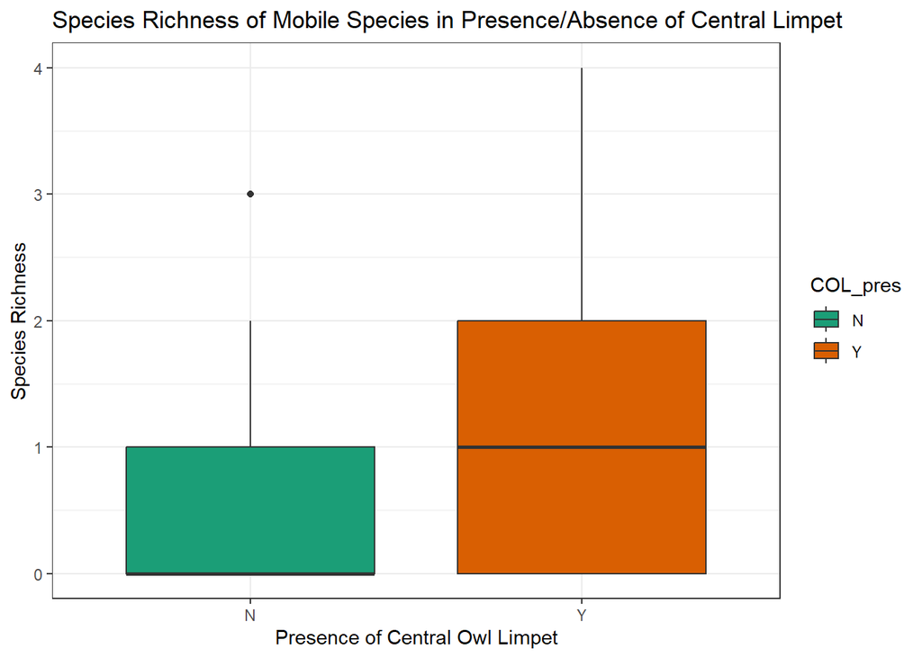

```r
mobile_spec_rich_box <- cnm_mob_count_mat_sum %>%
  ggplot(aes(
    x = COL_pres,
    y = spec_sum,
    fill = COL_pres))+
  geom_boxplot(show.legend = TRUE)+
  scale_fill_brewer(palette = "Dark2")+
  labs(title = "Species Richness of Mobile Species in Presence/Absence of Central Limpet",
       x = "Presence of Central Owl Limpet",
       y = "Species Richness")+
  theme_bw()
mobile_spec_rich_box
```

#ttest For Mobile Species Richness

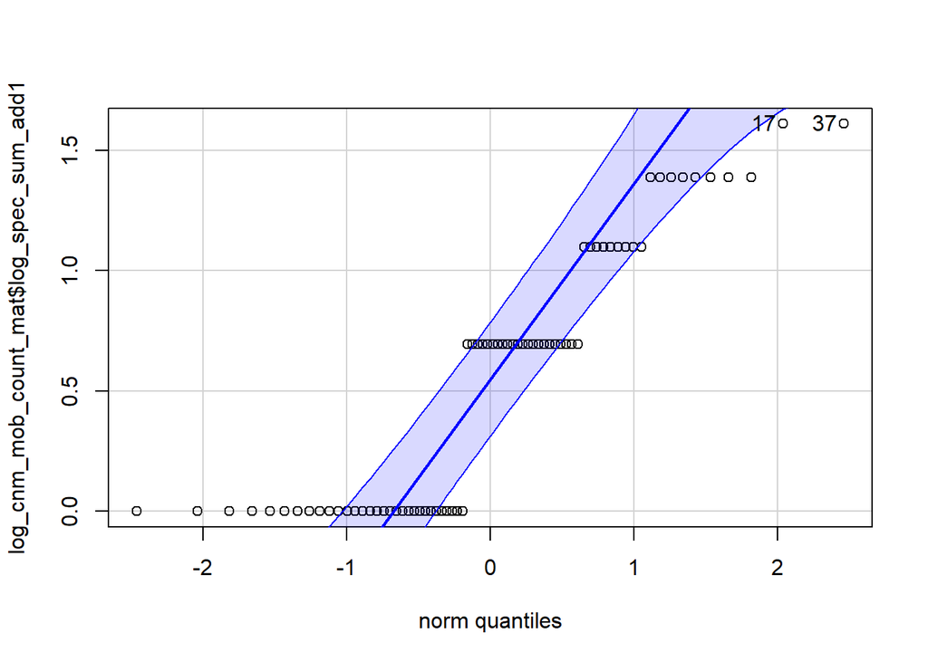

```
## [1] 17 37
```

```r
log_cnm_mob_count_mat <- cnm_mob_count_mat_sum %>%
  mutate(spec_sum_add1 = spec_sum+1) %>% #adding a constant so I can eliminate the 0 i data
  mutate(log_spec_sum_add1 = log(spec_sum_add1)) #transforming data with log fxn
qqp(log_cnm_mob_count_mat$log_spec_sum_add1, "norm") #test for normality, the zero's aren't falling within normality test
```

```r
shapiro.test(log_cnm_mob_count_mat$log_spec_sum_add1) #shapriro test shows low p value
```

```
##
##  Shapiro-Wilk normality test
##
## data:  log_cnm_mob_count_mat$log_spec_sum_add1
## W = 0.82409, p-value = 8.101e-08
```

```r
mob_t_test <- t.test(log_spec_sum_add1~COL_pres, data = log_cnm_mob_count_mat)
mob_t_test
```

```
##
##  Welch Two Sample t-test
##
## data:  log_spec_sum_add1 by COL_pres
## t = -2.6296, df = 68.775, p-value = 0.01054
## alternative hypothesis: true difference in means between group N and group Y is not equal to 0
## 95 percent confidence interval:
##  -0.5610519 -0.0769773
## sample estimates:
## mean in group N mean in group Y
##       0.3883535       0.7073681
```

#Sessile Species Richnnes Data Manipulation

```r
cnm_sessile_count_mat
```

```
## # A tibble: 71 × 12
##    Transect Plot_Name L_R   Meter_no COL_pres Tag_ID A_elegantissima
##    <chr>    <chr>     <chr>    <dbl> <chr>    <chr>            <dbl>
##  1 CNM_1    CNM_1_E_1 L            1 Y        0                    0
##  2 CNM_1    CNM_1_C_1 R            1 N        0                    0
##  3 CNM_1    CNM_1_E_2 R            2 Y        D002                 0
##  4 CNM_1    CNM_1_C_2 L            2 N        0                    0
##  5 CNM_1    CNM_1_E_3 L            3 Y        0                    0
##  6 CNM_1    CNM_1_C_3 R            3 N        0                    0
##  7 CNM_1    CNM_1_E_4 R            4 Y        D003                 0
##  8 CNM_1    CNM_1_C_4 L            4 N        0                    0
##  9 CNM_1    CNM_1_E_5 L            5 Y        0                    0
## 10 CNM_1    CNM_1_C_5 R            5 N        0                    0
## # ℹ 61 more rows
## # ℹ 5 more variables: Chthalmus_sp <dbl>, Bare_rock <dbl>, Ralfsia_sp <dbl>,
## #   P_polymerus <dbl>, Ulva_sp <dbl>
```

```r
cnm_sessile_count_mat$COL_pres <- as.factor(cnm_sessile_count_mat$COL_pres) #made this coulmn a factor
#cnm_sessile_count_mat$COL_pres_TF <- as.factor(cnm_sessile_count_mat$COL_pres_TF) #made this coulmn a factor THIS IMPORTANT FOR nMDS
cnm_sessile_count_mat$Transect<- as.factor(cnm_sessile_count_mat$Transect)

#cnm_sessile_count_mat_long <- cnm_sessile_count_mat %>%
  #pivot_longer(cols = A_lugubris:L_gigantea, #pivoted to make longer
               #names_to = "Species", #all species name in this column
               #values_to = "Values") %>%  #all counts of said species in this column, this can give me a count per species to get species richness
  #filter(Values != 0) %>% #take out any rows that have a count of 0, R was giving me problems. Some plots were selected againts since they had 0 for all species
 # group_by(COL_pres) %>% #group by presence or no presence of owl limpet
  #count(Species)

#Using this one
  cnm_sessile_count_mat_sum <- cnm_sessile_count_mat %>%
  mutate(spec_sum = rowSums(across(c(A_elegantissima,Chthalmus_sp, Bare_rock, Ralfsia_sp, P_polymerus, Ulva_sp)), na.rm=TRUE))
```

#Boxplot of Sessile Species Richness

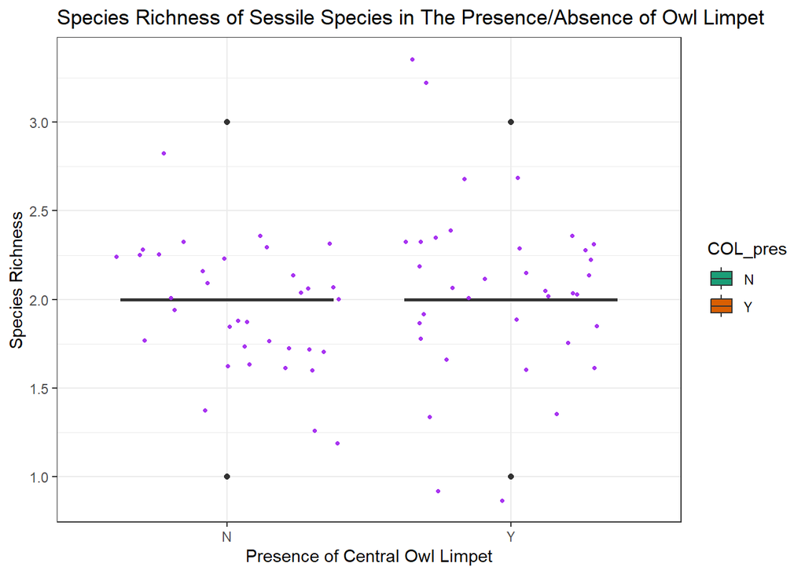

```r
sessile_spec_rich_box <- cnm_sessile_count_mat_sum %>%
  ggplot(aes(
    x = COL_pres,
    y = spec_sum,
    fill = COL_pres))+
  geom_boxplot(show.legend = TRUE)+
  scale_fill_brewer(palette = "Dark2")+
  labs(title = "Species Richness of Sessile Species in The Presence/Absence of Owl Limpet",
       x = "Presence of Central Owl Limpet",
       y = "Species Richness")+
    geom_jitter(color = "purple", size=0.9, alpha=0.9, show.legend = (FALSE))+
  theme_bw()
sessile_spec_rich_box
```

#Species Richness of Sessile Welchs T test

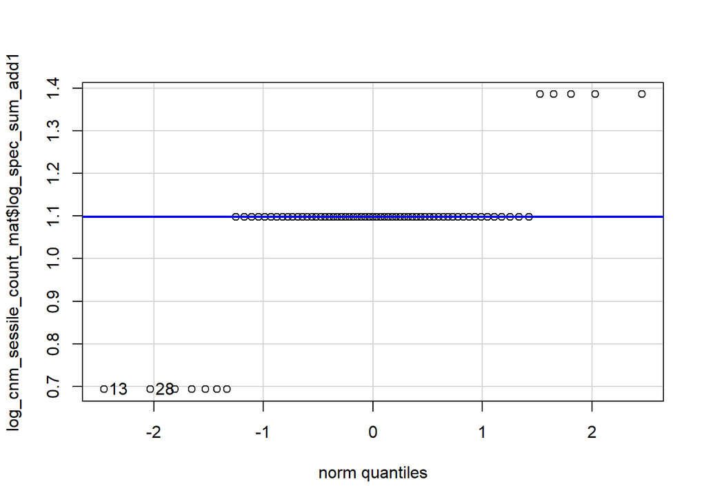

```
## [1] 13 28
```

```r
log_cnm_sessile_count_mat <- cnm_sessile_count_mat_sum %>%
  mutate(spec_sum_add1 = spec_sum+1) %>% #adding a constant so I can eliminate the 0 i data
  mutate(log_spec_sum_add1 = log(spec_sum_add1)) #transforming data with log fxn
qqp(log_cnm_sessile_count_mat$log_spec_sum_add1, "norm") #test for normality, the zero's aren't falling within normality test
```

```r
shapiro.test(log_cnm_sessile_count_mat$log_spec_sum_add1) #shapriro test shows low p value
```

```
##
##  Shapiro-Wilk normality test
##
## data:  log_cnm_sessile_count_mat$log_spec_sum_add1
## W = 0.55281, p-value = 2.244e-13
```

```r
sessile_t_test <- t.test(log_spec_sum_add1~COL_pres, data = log_cnm_sessile_count_mat)
sessile_t_test
```

```
##
##  Welch Two Sample t-test
##
## data:  log_spec_sum_add1 by COL_pres
## t = -0.38142, df = 65.239, p-value = 0.7041
## alternative hypothesis: true difference in means between group N and group Y is not equal to 0
## 95 percent confidence interval:
##  -0.08385564  0.05696032
## sample estimates:
## mean in group N mean in group Y
##        1.072078        1.085525
```

#Patchwork of species richness for mobiles and sessile

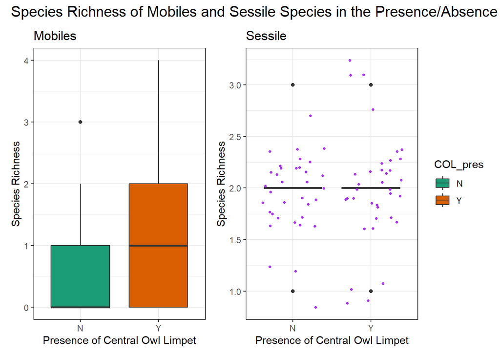

```r
mobile_spec_rich_box_nolab <- cnm_mob_count_mat_sum %>%
  ggplot(aes(
    x = COL_pres,
    y = spec_sum,
    fill = COL_pres))+
  geom_boxplot(show.legend = FALSE)+
  scale_fill_brewer(palette = "Dark2")+
  labs(title = "Mobiles",
       x = "Presence of Central Owl Limpet",
       y = "Species Richness")+
  theme_bw()

sessile_spec_rich_nolab <- cnm_sessile_count_mat_sum %>%
  ggplot(aes(
    x = COL_pres,
    y = spec_sum,
    fill = COL_pres))+
  geom_boxplot(show.legend = TRUE)+
  scale_fill_brewer(palette = "Dark2")+
  labs(title = "Sessile",
       x = "Presence of Central Owl Limpet",
       y = "Species Richness")+
    geom_jitter(color = "purple", size=0.9, alpha=0.9, show.legend = (FALSE))+
  theme_bw()


mobile_spec_rich_box_nolab+sessile_spec_rich_nolab+
  plot_annotation(title = 'Species Richness of Mobiles and Sessile Species in the Presence/Absence of Owl Limpets',
                  theme = theme(plot.title = element_text(size = 15)))
```

#Patchwork of Mobile Abundance and Sessile Percent Cover

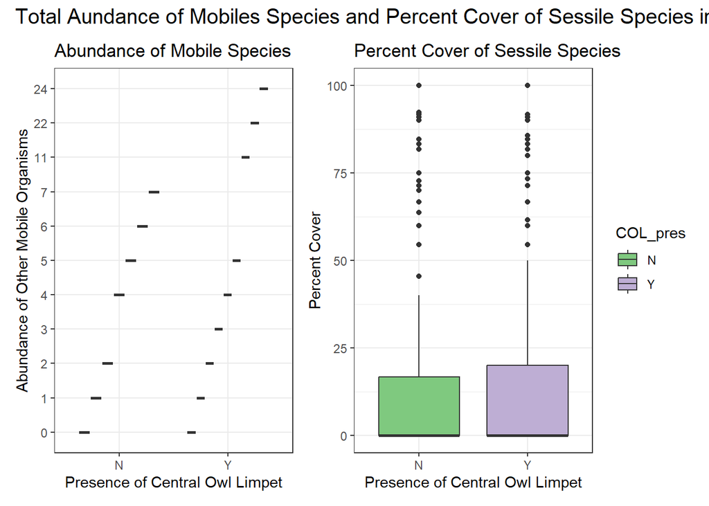

```r
 patch_mob <- cnm_mobiles_sum_spec %>%
  ggplot(aes(
    x = COL_pres,
    y = spec_sum,
    fill = COL_pres))+
  geom_boxplot(show.legend = FALSE)+
  scale_fill_brewer(palette = "Accent")+
  labs(title = "Abundance of Mobile Species",
       x = "Presence of Central Owl Limpet",
       y = "Abundance of Other Mobile Organisms") +
  theme_bw()

patch_sess <- cnm_sessile_sum_plot %>%
  ggplot(aes(
    x = COL_pres,
    y = percent_cover,
    fill = COL_pres))+
  geom_boxplot(show.legend = TRUE)+
  scale_fill_brewer(palette = "Accent")+
  labs(title = "Percent Cover of Sessile Species",
       x = "Presence of Central Owl Limpet",
       y = "Percent Cover") +
  theme_bw()

patch_mob+patch_sess+
  plot_annotation(title = 'Total Aundance of Mobiles Species and Percent Cover of Sessile Species in the Presence/Absence of Owl Limpets', theme = theme(plot.title = element_text(size = 15)))
```